# Career Motivation

### [Home](https://pbischoff3.github.io/) | [Data Overview](https://pbischoff3.github.io/data_overview/) | [Multi-Dimensional Analysis](https://pbischoff3.github.io/multi_dimensional_analysis/) | [Models](https://pbischoff3.github.io/models/) | [Conclusion](https://pbischoff3.github.io/Conclusion/)

#### [Science Identity](https://pbischoff3.github.io/models/si/) | [Career Motivation](https://pbischoff3.github.io/models/cm/) | [Intrinsic Motivation](https://pbischoff3.github.io/models/im/) | [Self-Determination](https://pbischoff3.github.io/models/sd/) | [Self-Efficacy](https://pbischoff3.github.io/models/se/) | [Grade Motivation](https://pbischoff3.github.io/models/gm) | [Personal Communal Orientation](https://pbischoff3.github.io/models/per_com_orient/) | [Analysis](https://pbischoff3.github.io/models/analysis/)

Let’s check out Career Motivation models.

## Major

Let’s see the influence that the difference in majors have an the average of Career Motivation questions:

```
##
## Call:
## glm(formula = career_mot_ave ~ major, data = df)
##
## Deviance Residuals:
##     Min       1Q   Median       3Q      Max
## -3.0648  -0.3157   0.5352   0.9352   1.7143
##
## Coefficients:
##                   Estimate Std. Error t value Pr(>|t|)
## (Intercept)        4.06479    0.15865  25.621   <2e-16 ***
## majorChemistry    -0.77907    0.52960  -1.471   0.1423
## majorComputer_sci  0.33521    0.52960   0.633   0.5272
## majorEarth_sci     0.73521    1.34622   0.546   0.5854
## majorEngineering   0.44188    0.37989   1.163   0.2457
## majorHealth_sci   -0.12193    0.19177  -0.636   0.5254
## majorMathematics  -0.06479    0.95851  -0.068   0.9462
## majorNon_STEM     -0.63870    0.32074  -1.991   0.0473 *
## majorOther        -0.20854    0.28464  -0.733   0.4643
## ---
## Signif. codes:  0 '***' 0.001 '**' 0.01 '*' 0.05 '.' 0.1 ' ' 1
##
## (Dispersion parameter for gaussian family taken to be 1.787129)
##
##     Null deviance: 558.92  on 311  degrees of freedom
## Residual deviance: 541.50  on 303  degrees of freedom
## AIC: 1077.4
##
## Number of Fisher Scoring iterations: 2
```

This is great, but it is difficult to understand this in context until we compare it to the other models.

## Career

Now, let’s look at how career goals affect the average of Career Motivation questions:

```
##
## Call:
## glm(formula = career_mot_ave ~ career, data = df)
##
## Deviance Residuals:
##     Min       1Q   Median       3Q      Max
## -3.2500  -0.3705   0.5694   1.0246   1.4100
##
## Coefficients:
##                        Estimate Std. Error t value Pr(>|t|)
## (Intercept)            3.968889   0.199665  19.878   <2e-16 ***
## careereducator        -0.122735   0.421740  -0.291    0.771
## careerengineer         0.431111   0.399330   1.080    0.281
## careerhealth_care_pro  0.006521   0.233604   0.028    0.978
## careermedical_doctor  -0.138333   0.254524  -0.543    0.587
## careernon_stem        -0.578889   0.359952  -1.608    0.109
## careerresearcher       0.631111   0.544196   1.160    0.247
## careerscientist        0.281111   0.435160   0.646    0.519
## careertechnician       0.331111   0.582119   0.569    0.570
## ---
## Signif. codes:  0 '***' 0.001 '**' 0.01 '*' 0.05 '.' 0.1 ' ' 1
##
## (Dispersion parameter for gaussian family taken to be 1.793979)
##
##     Null deviance: 558.92  on 311  degrees of freedom
## Residual deviance: 543.58  on 303  degrees of freedom
## AIC: 1078.6
##
## Number of Fisher Scoring iterations: 2
```

Now let’s run from another model’s point of view.

## Ethnicity

How about we look at how different ethnicities affect Career Motivation?

```
##
## Call:
## glm(formula = career_mot_ave ~ ethnicity, data = df)
##
## Deviance Residuals:
##     Min       1Q   Median       3Q      Max
## -3.2667  -0.2882   0.5660   0.9660   3.2000
##
## Coefficients:
##                            Estimate Std. Error t value Pr(>|t|)
## (Intercept)                  1.8000     0.5764   3.123 0.001964 **
## ethnicityamerican_indian     2.2500     0.8646   2.602 0.009713 **
## ethnicityarab                3.2000     1.4118   2.267 0.024126 *
## ethnicityasian               1.4222     0.7189   1.978 0.048793 *
## ethnicitybiracial            2.4667     0.7189   3.431 0.000684 ***
## ethnicitylatinx              2.3529     0.6557   3.588 0.000388 ***
## ethnicityother              -0.8000     1.4118  -0.567 0.571383
## ethnicitypacific_islander    1.6000     0.9412   1.700 0.090179 .
## ethnicityprefer_not_answer   0.2000     0.8646   0.231 0.817217
## ethnicitywhite               2.2340     0.5819   3.839 0.000151 ***
## ---
## Signif. codes:  0 '***' 0.001 '**' 0.01 '*' 0.05 '.' 0.1 ' ' 1
##
## (Dispersion parameter for gaussian family taken to be 1.661089)
##
##     Null deviance: 558.92  on 311  degrees of freedom
## Residual deviance: 501.65  on 302  degrees of freedom
## AIC: 1055.6
##
## Number of Fisher Scoring iterations: 2
```

This shows that African-Americans have a significantly lower Career Motivation, while American Indians, Arabs, Asians, those who are Biracial, Latinx, and Caucasians have a significantly higher Career Motivation.

One last model. Let’s check it out.

## Medical Conditions

Here is the model according to a presence of medical conditions or not.

```
##
## Call:
## glm(formula = career_mot_ave ~ med_condition, data = df)
##
## Deviance Residuals:
##     Min       1Q   Median       3Q      Max
## -3.3897  -0.3123   0.5136   1.1136   1.1136
##
## Coefficients:
##                  Estimate Std. Error t value Pr(>|t|)
## (Intercept)       3.88645    0.08064  48.198   <2e-16 ***
## med_conditionYes  0.50330    0.22807   2.207   0.0281 *
## ---
## Signif. codes:  0 '***' 0.001 '**' 0.01 '*' 0.05 '.' 0.1 ' ' 1
##
## (Dispersion parameter for gaussian family taken to be 1.775083)
##
##     Null deviance: 558.92  on 311  degrees of freedom
## Residual deviance: 550.28  on 310  degrees of freedom
## AIC: 1068.5
##
## Number of Fisher Scoring iterations: 2
```

This shows that those who do not have medical conditions have a significantly lower Career Motivation.

## Conclusion

Now that we have those 4 models according to the demographic that we are interested in, let’s compare them against each other to see which models were best in determining Career Motivation.

```
## Parameter                     |       cm_mod_1 |        cm_mod_2 |       cm_mod_3 |       cm_mod_4
## --------------------------------------------------------------------------------------------------
## (Intercept)                   | 4.06*** (0.16) |  3.97*** (0.20) |  1.80** (0.58) | 3.89*** (0.08)
## major (Computer sci)          |    0.34 (0.53) |                 |                |
## major (Earth sci)             |    0.74 (1.35) |                 |                |
## major (Engineering)           |    0.44 (0.38) |                 |                |
## major (Chemistry)             |   -0.78 (0.53) |                 |                |
## major (Mathematics)           |   -0.06 (0.96) |                 |                |
## major (Non STEM)              |  -0.64* (0.32) |                 |                |
## major (Other)                 |   -0.21 (0.28) |                 |                |
## major (Health sci)            |   -0.12 (0.19) |                 |                |
## career (engineer)             |                |     0.43 (0.40) |                |
## career (health care pro)      |                | 6.52e-03 (0.23) |                |
## career (medical doctor)       |                |    -0.14 (0.25) |                |
## career (educator)             |                |    -0.12 (0.42) |                |
## career (researcher)           |                |     0.63 (0.54) |                |
## career (scientist)            |                |     0.28 (0.44) |                |
## career (technician)           |                |     0.33 (0.58) |                |
## career (non stem)             |                |    -0.58 (0.36) |                |
## ethnicity (asian)             |                |                 |   1.42* (0.72) |
## ethnicity (biracial)          |                |                 | 2.47*** (0.72) |
## ethnicity (american indian)   |                |                 |  2.25** (0.86) |
## ethnicity (arab)              |                |                 |   3.20* (1.41) |
## ethnicity (pacific islander)  |                |                 |    1.60 (0.94) |
## ethnicity (prefer not answer) |                |                 |    0.20 (0.86) |
## ethnicity (latinx)            |                |                 | 2.35*** (0.66) |
## ethnicity (other)             |                |                 |   -0.80 (1.41) |
## ethnicity (white)             |                |                 | 2.23*** (0.58) |
## med condition (Yes)           |                |                 |                |   0.50* (0.23)
## --------------------------------------------------------------------------------------------------
## Observations                  |            312 |             312 |            312 |            312
```

This shows everything that we have performed thus far, but now let’s add some statistical analysis to it.

```
## # Comparison of Model Performance Indices
##
## Name     | Model |      AIC | AIC weights |      BIC | BIC weights |    R2 |  RMSE | Sigma
## ------------------------------------------------------------------------------------------
## cm_mod_1 |   glm | 1077.436 |     < 0.001 | 1114.866 |     < 0.001 | 0.031 | 1.317 | 1.337
## cm_mod_2 |   glm | 1078.629 |     < 0.001 | 1116.059 |     < 0.001 | 0.027 | 1.320 | 1.339
## cm_mod_3 |   glm | 1055.586 |       0.998 | 1096.759 |     < 0.001 | 0.102 | 1.268 | 1.289
## cm_mod_4 |   glm | 1068.452 |       0.002 | 1079.681 |       1.000 | 0.015 | 1.328 | 1.332
```

To put all of this in English, we are most interested in those that have higher R^2 values and lower BIC, AIC, and RMSE values. According to that knowledge, it looks like Ethnicity and Medical Conditions are the best predictor for Career Motivation. Let’s see these together, and with that, we can see whether how they relate.

```
##
## Call:
## glm(formula = career_mot_ave ~ ethnicity + med_condition, data = df)
##
## Deviance Residuals:
##     Min       1Q   Median       3Q      Max
## -3.6154  -0.3815   0.4185   1.0185   3.2000
##
## Coefficients:
##                            Estimate Std. Error t value Pr(>|t|)
## (Intercept)                 1.80000    0.57221   3.146 0.001823 **
## ethnicityamerican_indian    1.98844    0.86564   2.297 0.022301 *
## ethnicityarab               3.20000    1.40163   2.283 0.023124 *
## ethnicityasian              1.30597    0.71542   1.825 0.068922 .
## ethnicitybiracial           2.29229    0.71759   3.194 0.001550 **
## ethnicitylatinx             2.22985    0.65309   3.414 0.000727 ***
## ethnicityother             -0.80000    1.40163  -0.571 0.568585
## ethnicitypacific_islander   1.42562    0.93742   1.521 0.129359
## ethnicityprefer_not_answer  0.06922    0.86015   0.080 0.935916
## ethnicitywhite              2.18146    0.57815   3.773 0.000194 ***
## med_conditionYes            0.52313    0.22471   2.328 0.020575 *
## ---
## Signif. codes:  0 '***' 0.001 '**' 0.01 '*' 0.05 '.' 0.1 ' ' 1
##
## (Dispersion parameter for gaussian family taken to be 1.637131)
##
##     Null deviance: 558.92  on 311  degrees of freedom
## Residual deviance: 492.78  on 301  degrees of freedom
## AIC: 1052
##
## Number of Fisher Scoring iterations: 2
```

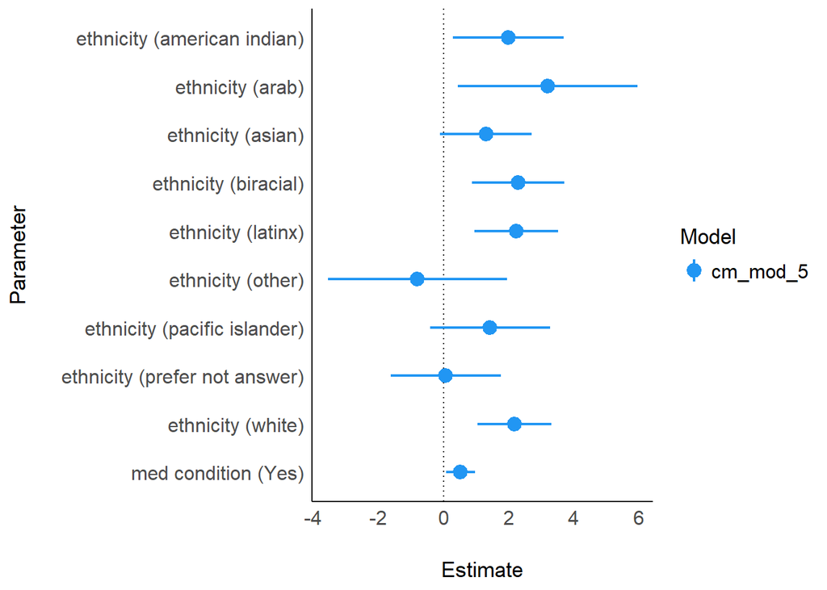

Well awesome, this gives us a great place that we can start in further data analysis in our project.

[figure not shown]

### [**NEXT**](https://pbischoff3.github.io/models/im/)